# TFA exam - Guiding solution

Lars Relund Nielsen

# R - Assignment 1 (55%)

Given a company, consider the dataset in the file `mrp.csv` containing a Material Requirements Plan (MRP) for a group of materials. For each combination of week, material, and supplier, a row is given with information about inventory, requirements, etc.

The columns/variables are:

- `week`: Week number (consider weeks 8 to 37). [in the original exam typo 30 was used instead of 37]
- `material_id`: Material id.
- `supplier_id`: Supplier id, i.e. the vendor the material is bought from.
- `supplier_desc`: Supplier description.
- `moq`: Minimum order quantity from supplier in units.
- `inventory_ini`: Initial inventory of the material in the start of week 8.
- `reqs`: Material requirements for the week. Note: inventory levels and requirements are given for fixed material and supplier.

The dataset can be read using:

```r
library(tidyverse)
dat <- read_csv("mrp.csv")
```

Use the *dplyr* package in *tidyverse* to calculate relevant summary tables (tibbles/data frames), and answer/complete the following questions/tasks:

## Question 1

How many different weeks, materials and suppliers are considered?

```r
# load packages
library(tidyverse)
library(skimr)
res <- dat |>
   skim() |>
   print()
```

```
## ── Data Summary ────────────────────────
##                            Values
## Name                       dat
## Number of rows             9690
## Number of columns          7
## _______________________
## Column type frequency:
##   character                3
##   numeric                  4
## ________________________
## Group variables            None
##
## ── Variable type: character ──────────────────────────────────────────────────────────────
##   skim_variable n_missing complete_rate min max empty n_unique whitespace
## 1 material_id           0         1       9   9     0      267          0
## 2 supplier_id           0         1       7   8     0       10          0
## 3 supplier_desc        30         0.997   5  18     0        9          0
##
## ── Variable type: numeric ────────────────────────────────────────────────────────────────
##   skim_variable n_missing complete_rate     mean         sd      p0    p25      p50    p75
## 1 week                  0         1         22.5       8.66       8     15     22.5     30
## 2 moq                  30         0.997 329174.   166212.      1001 147000 400000   400000
## 3 inventory_ini         0         1     797755.  2390229.         0  39809 195676   562320
## 4 reqs                  0         1      42454.   525094.   -200000      0      0        0
##        p100 hist
## 1       37  ▇▇▇▇▇
## 2   500000  ▃▁▁▇▃
## 3 30935801. ▇▁▁▁▁
## 4 20600000  ▇▁▁▁▁
```

We consider 30 weeks, 267 materials supplied by 10 suppliers.

## Question 2

Find the number of different materials required from each supplier. How many materials are required from the supplier with most different materials?

```r
res <- dat |>
   group_by(supplier_id) |>
   summarise(n = n_distinct(material_id)) |>
   arrange(desc(n)) |>
   print()
```

```
## # A tibble: 10 × 2
##    supplier_id     n
##    <chr>       <int>
##  1 S369645       102
##  2 S3010406       71
##  3 S329057        65
##  4 S372717        33
##  5 S330660        23
##  6 S337463        23
##  7 S314507         3
##  8 S314951         1
##  9 S388143         1
## 10 S397898         1
```

Supplier S369645 sell 102 different materials to the company.

## Question 3

For each material, calculate how many suppliers supply the specific material. How many suppliers sell material `M51136441`?

```r
res <- dat |>
   group_by(material_id) |>
   summarize(n = n_distinct(supplier_id)) |>
   arrange(desc(n)) |>
   print()
```

```
## # A tibble: 267 × 2
##    material_id     n
##    <chr>       <int>
##  1 M51104291       4
##  2 M51136084       3
##  3 M51156610       3
##  4 M51325788       3
##  5 M51333862       3
##  6 M51342330       3
##  7 M51395586       3
##  8 M51419117       3
##  9 M51136441       2
## 10 M51226330       2
## # ℹ 257 more rows
```

The number of suppliers are calculated above (see `res`). Material `M51136441` is sold by 2 suppliers.

## Question 4

Consider a material and a supplier. Note that the column `inventory_ini` contains the initial inventory level before the first week (week 8). Hence, for a row, the ultimo inventory level (end of week level) is calculated as the initial inventory level minus all the requirements up to and including the current week. Create a column `inventory_ultimo` with the ultimo inventory values. Hint: Given a group, the `cumsum` function can be used to add all values up to and including the current row.

```r
dat <- dat |>
   group_by(material_id, supplier_id) |>
   mutate(
      inventory_ultimo = inventory_ini - cumsum(reqs)
   ) |>
   print()
```

```
## # A tibble: 9,690 × 8
## # Groups:   material_id, supplier_id [323]
##     week material_id supplier_id supplier_desc    moq inventory_ini  reqs inventory_ultimo
##    <dbl> <chr>       <chr>       <chr>          <dbl>         <dbl> <dbl>            <dbl>
##  1     8 M51104291   S330660     CanPack BNL_DE   4e5             0     0                0
##  2     9 M51104291   S330660     CanPack BNL_DE   4e5             0     0                0
##  3    10 M51104291   S330660     CanPack BNL_DE   4e5             0     0                0
##  4    11 M51104291   S330660     CanPack BNL_DE   4e5             0     0                0
##  5    12 M51104291   S330660     CanPack BNL_DE   4e5             0     0                0
##  6    13 M51104291   S330660     CanPack BNL_DE   4e5             0     0                0
##  7    14 M51104291   S330660     CanPack BNL_DE   4e5             0     0                0
##  8    15 M51104291   S330660     CanPack BNL_DE   4e5             0     0                0
##  9    16 M51104291   S330660     CanPack BNL_DE   4e5             0     0                0
## 10    17 M51104291   S330660     CanPack BNL_DE   4e5             0     0                0
## # ℹ 9,680 more rows
```

We group by `material_id` and `supplier_id` and find the ultimo inventory.

## Question 5

For each material, calculate the total requirements and ultimo inventory for each week. How many materials have a negative ultimo inventory in one of the weeks?

```r
res1 <- dat |>
   group_by(material_id, week) |>
   summarise(reqs = sum(reqs), inventory_ultimo = sum(inventory_ultimo)) |>
   print()
```

```
## # A tibble: 8,010 × 4
## # Groups:   material_id [267]
##    material_id  week  reqs inventory_ultimo
##    <chr>       <dbl> <dbl>            <dbl>
##  1 M51104291       8     0         16959824
##  2 M51104291       9     0         16959824
##  3 M51104291      10     0         16959824
##  4 M51104291      11     0         16959824
##  5 M51104291      12     0         16959824
##  6 M51104291      13     0         16959824
##  7 M51104291      14     0         16959824
##  8 M51104291      15     0         16959824
##  9 M51104291      16     0         16959824
## 10 M51104291      17     0         16959824
## # ℹ 8,000 more rows
```

```r
res2 <- res1 |>
   group_by(material_id) |>
   summarise(shortage = any(inventory_ultimo < 0)) |>
   summarise(n = sum(shortage)) |>
   print()
```

```
## # A tibble: 1 × 1
##       n
##   <int>
## 1   148
```

We find the the total requirements and ultimo inventory for each week by grouping by material and week. Next, we use the dataset to calculate that 148 materials have a negative ultimo inventory in one of the weeks.

## Question 6

A dataset with material info is given in the file `materials.csv`.

The columns/variables are:

- `material_id`: Material id.
- `material_desc`: Material description.
- `material_group_id`: Material group id.
- `marterial_group_desc`: Material group description.
- `abcd`: Inventory classification.

The dataset can be read using:

```r
dat_mat <- read_csv("materials.csv")
```

Answer the following questions:

- How many different materials are there in each inventory classification group?
- Does there exist material groups represented in more than one inventory classification group?
- Join the dataset with the MRP dataset. For each material group, calculate the number of suppliers, largest ultimo inventory in a week and the corresponding material used. Hint: To find the corresponding material, you have to create a second dataset and then join the results.

```r
res <- dat_mat |>
   group_by(abcd) |>
   summarise(n = n_distinct(material_id)) |>
   print()
```

```
## # A tibble: 4 × 2
##   abcd      n
##   <chr> <int>
## 1 A        91
## 2 B        32
## 3 C       130
## 4 D        14
```

There are e.g. 32 different materials in Group B.

```r
res <- dat_mat |>
   group_by(material_group_id) |>
   summarise(n = n_distinct(abcd)) |>
   arrange(desc(n)) |>
   print()
```

```
## # A tibble: 10 × 2
##    material_group_id     n
##    <chr>             <int>
##  1 MG20301               4
##  2 MG2030201             4
##  3 MG2080101             4
##  4 MG20302               3
##  5 MG20304               3
##  6 MG2080102             3
##  7 MG2030302             1
##  8 MG2080202             1
##  9 MG2080203             1
## 10 MG20901               1
```

There are some material groups that are in different inventory classification groups.

```r
# Join datasets
dat <- dat %>%
   left_join(dat_mat)

res1 <- dat |>
   group_by(material_group_id) |>
   summarise(n = n_distinct(supplier_id), inv_max = max(inventory_ultimo), ) |>
   arrange(desc(n)) |>
   print()
```

```
## # A tibble: 10 × 3
##    material_group_id     n   inv_max
##    <chr>             <int>     <dbl>
##  1 MG20304               5 30935801.
##  2 MG20301               4  7327190
##  3 MG2030201             4 16661259
##  4 MG20302               2   727345
##  5 MG2080101             2  2661444
##  6 MG2080102             2   333656.
##  7 MG2030302             1    11837
##  8 MG2080202             1      593.
##  9 MG2080203             1    16594.
## 10 MG20901               1   414000
```

```r
# find the corresponding material for the maximum inventory
res2 <- dat %>%
   group_by(material_group_id) %>%
   filter(inventory_ultimo == max(inventory_ultimo, na.rm = TRUE)) %>%
   select(material_group_id, material_id) %>%
   distinct() |>
   print()
```

```
## # A tibble: 10 × 2
## # Groups:   material_group_id [10]
##    material_group_id material_id
##    <chr>             <chr>
##  1 MG2030201         M51342678
##  2 MG2080101         M51312767
##  3 MG2080202         M51338387
##  4 MG2080102         M51133046
##  5 MG2080203         M51306226
##  6 MG20304           M51136084
##  7 MG20901           M51337620
##  8 MG20302           M51376930
##  9 MG2030302         M51383324
## 10 MG20301           M51348992
```

```r
# Merge the results to include the corresponding material
res <- res1 %>%
  left_join(res2) |> print()
```

```
## # A tibble: 10 × 4
##    material_group_id     n   inv_max material_id
##    <chr>             <int>     <dbl> <chr>
##  1 MG20304               5 30935801. M51136084
##  2 MG20301               4  7327190  M51348992
##  3 MG2030201             4 16661259  M51342678
##  4 MG20302               2   727345  M51376930
##  5 MG2080101             2  2661444  M51312767
##  6 MG2080102             2   333656. M51133046
##  7 MG2030302             1    11837  M51383324
##  8 MG2080202             1      593. M51338387
##  9 MG2080203             1    16594. M51306226
## 10 MG20901               1   414000  M51337620
```

First we find, for each material group, the number of suppliers, highest ultimo inventory in a week. Next the corresponding material used is found and then we join to get the results.

# R - Assignment 2 (45%)

Answer this assignment using the *ggplot2* package in *tidyverse* (you may need *dplyr* for preparing the datasets you want to plot). Work with a slightly modified dataset from Assignment 1, which can be read using:

```r
library(tidyverse)
dat <- read_csv("mrp-joined.csv")
```

The columns/variables are as mentioned in Assignment 1 except now all values have been summarized over all suppliers. Moreover, included is also this column/variable:

- `inventory_ultimo`: Ultimo inventory (end of the week) for the material.

## Question 1

Create a visualization showing the number of materials in each material group with the following features:

- Bars are used for each material group ordered such that the height of the bars decreases over the x-axis.
- The material group description is shown at the x-axis (rotated 90 degrees).
- Informative figure title and axis titles are given.

Which material group has the highest number of materials?

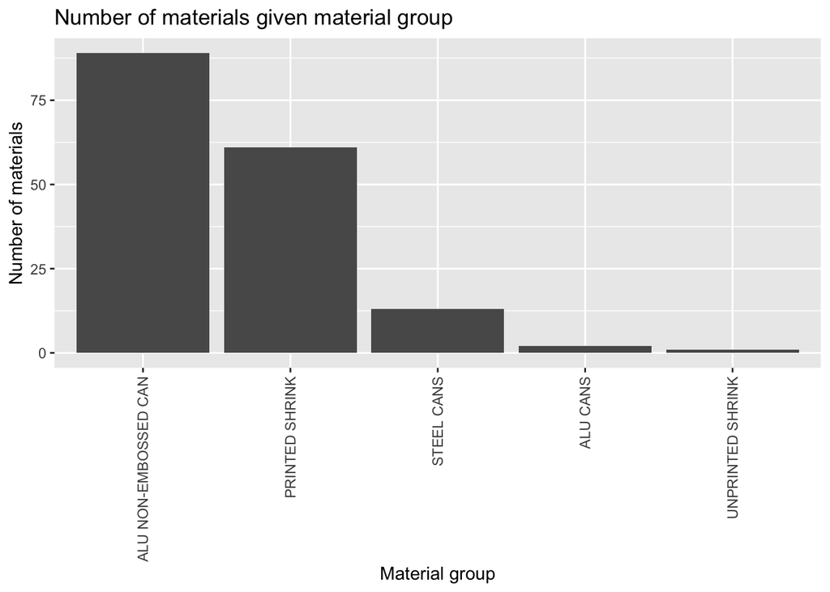

```r
dat |>
   group_by(material_group_desc) |>
   summarize(n = n_distinct(material_id)) |>
   ggplot(aes(
      x = reorder(material_group_desc, -n),
      y = n
   )) +
   geom_col() +
   labs(
      title = "Number of materials given material group",
      x = "Material group", y = "Number of materials"
   ) +
   theme(legend.position = "bottom",
         axis.text.x = element_text(angle = 90, vjust = 0.5, hjust=1)
   )
```

## Question 2

Create a visualization showing the total ultimo inventory for each material group with the following features:

- Lines are used for each material group. Hint: Using `geom_step` instead of `geom_line` may give a better visualization.
- Points are used to show data values. Moreover, the point color is used to identify if the ultimo inventory is negative. Hint: You need to define a new column with different values depending on whether the ultimo inventory is negative or positive.
- Line types are used to identify the material group.
- Informative figure title and axis titles are given.

Which material group has positive inventory in the last week?

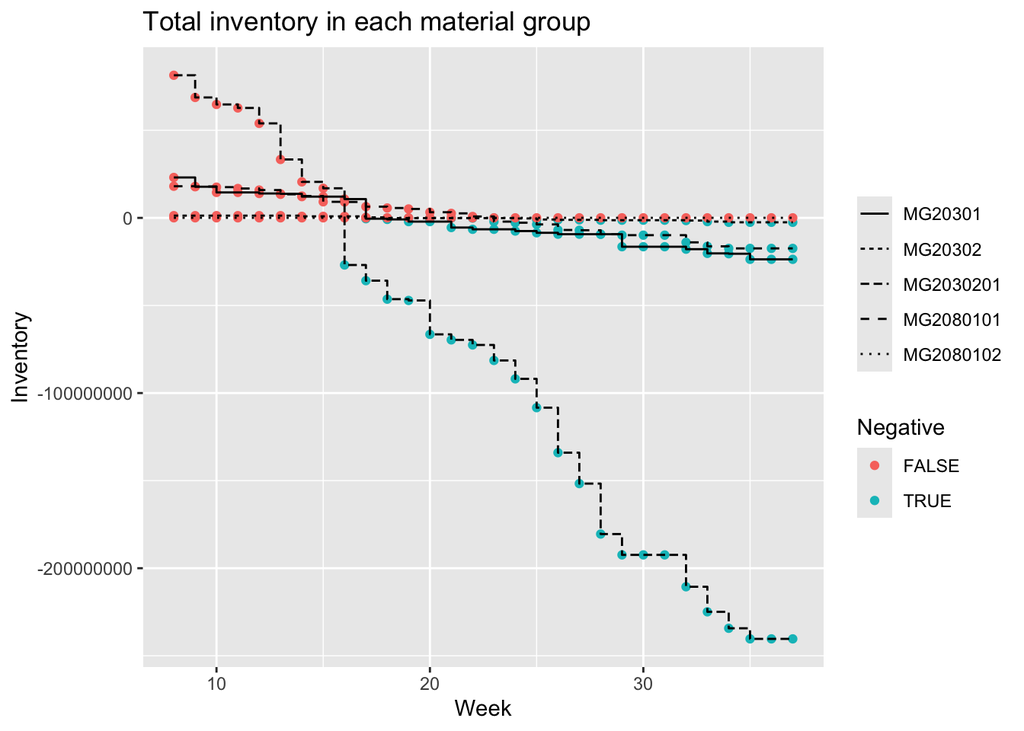

```r
dat |>
   group_by(week, material_group_id) |>
   summarise(inventory_ultimo = sum(inventory_ultimo)) |>
   mutate(negative = if_else(inventory_ultimo < 0, TRUE, FALSE)) |>
   arrange(desc(week)) |>
   ggplot(aes(x = week, y = inventory_ultimo, linetype = material_group_id)) +
   geom_point(aes(color = negative)) +
   geom_step() +
   labs(title = "Total inventory in each material group",
       x = "Week", y = "Inventory", linetype = NULL, color = "Negative")
```

The only group with positive inventory in the last week is UNPRINTED SHRINK (MG2080102).

## Question 3

Consider materials with these ids:

```r
mat_ids <- c("M51212503", "M51327609", "M51331501",
             "M51344118", "M51408045", "M51342678")
```

Create a visualization showing the variation of the weekly requirements for the 6 materials with the following features:

- A density is visualized for each material.
- Fill colors are used to identify the inventory classification.
- A plot is made for each material (facet).
- Legends are added at the bottom of the plot.
- Informative figure title and axis titles are given.

Consider the plots. Comment on the approximate value of the mean based on the plots.

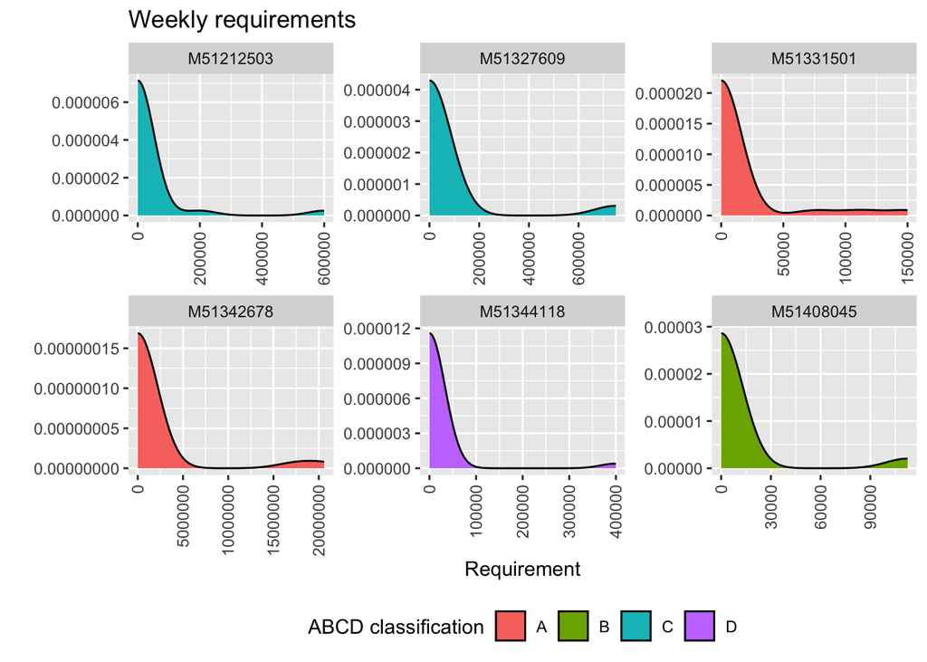

```r
dat |>
   filter(material_id %in% mat_ids) |>
   ggplot(aes(x = reqs, fill = abcd)) +
   geom_density() +
   facet_wrap(vars(material_id), scales = "free") +
   labs(title = "Weekly requirements",
       x = "Requirement", y = "", fill = "ABCD classification") +
   theme(legend.position = "bottom",
         axis.text.x = element_text(angle = 90, vjust = 0.5, hjust=1)
   )
```

The mean is in the area from zero to the distribution drops (lower end), that may be due to that often there are no requirements in a selected week.

## Question 4

Negative inventories are unfavourable, and the company applies an ordering policy to get materials before negative inventories occur. Load the dataset with arrival orders using:

```r
dat <- read_csv(file = "mrp-w-arrivals.csv")
```

New columns are:

- `inventory_primo`: the primo inventory (before arrival).
- `arrive_primo`: units that arrive primo in a week.

Moreover, the column `inventory_ultimo` contains updated values.

Create a visualization showing the total ultimo inventory in each inventory classification over the weeks with the following features:

- A line is used for each inventory classification.
- Colors are used to identify inventory classification.
- Legends are added at the bottom of the plot.
- Informative figure title and axis titles are given.

Which inventory classification has the highest inventory levels?

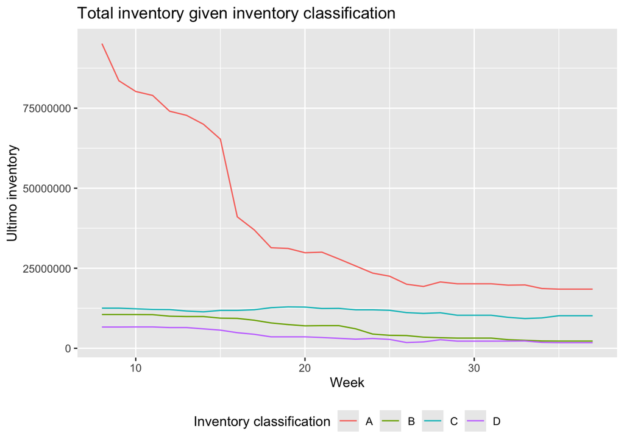

```r
dat %>%
   group_by(abcd, week) %>%
   summarize(total_inventory = sum(inventory_ultimo)) |>
   ggplot(aes(x = week, y = total_inventory, color = abcd)) +
   geom_line() +
   labs(title = "Total inventory given inventory classification",
       x = "Week", y = "Ultimo inventory", color = "Inventory classification") +
   theme(legend.position = "bottom")
```

Inventory classification A has the highest levels.

## Question 5

Create a visualization showing the inventory levels over the weeks for material `M51331501` with the following features:

- Bars are used to visualize the requirements with a fixed blue fill color. Hint: You may use `width = 0.25` to make the width smaller.
- A line is used to visualize the inventory level before the requirements are satisfied, i.e. `inventory_primo + arrive_primo`.
- Points are used to visualize `inventory_primo + arrive_primo`. Use different colors depending on whether units arrive or not.
- Legends are added at the bottom of the plot.
- Informative figure title and axis titles are given.

How many times do units arrive?

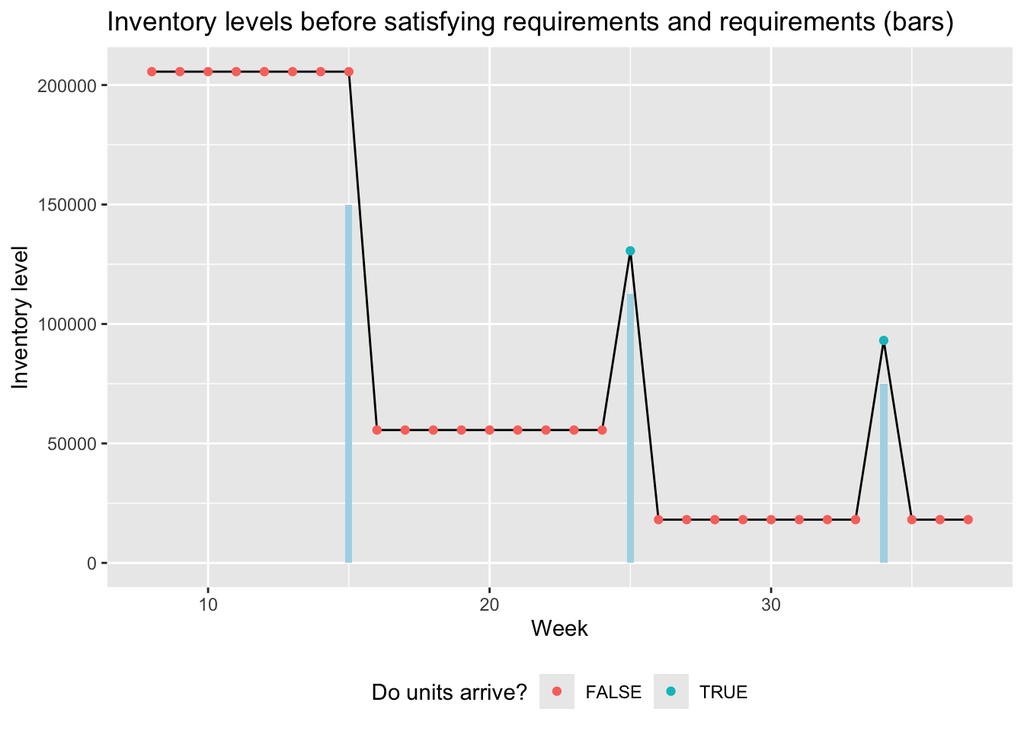

```r
mat_ids <- c("M51331501")
dat |>
   filter(material_id %in% mat_ids) |>
   ggplot(aes(x = week, y = inventory_primo + arrive_primo)) +
   geom_col(aes(y = reqs), width = 0.25, fill = "lightblue") +
   geom_line() +
   geom_point(aes(color = arrive_primo > 0)) +
   labs(title = "Inventory levels before satisfying requirements and requirements (bars)",
       x = "Week", y = "Inventory level", color = "Do units arrive?") +
   theme(legend.position = "bottom")
```

We have two arrivals (2 points).